# Quality report INS_Inschrijvingen_1CHO_VUdata_cookbook

Autogenerated data summary from dataMaid

2024-01-19 11:21:12.365339

# Data report overview

The dataset examined has the following dimensions:

| Feature | Result |
| --- | --- |
| Number of observations | 369116 |
| Number of variables | 106 |

# Codebook summary table

| Label | Variable | Class | # unique values | Missing | Description |
| --- | --- | --- | --- | --- | --- |
|  | **INS_Instelling** | character | 2 | 0.00 % |  |
|  | **INS_Versie_1CHO_jaar** | numeric | 1 | 0.00 % |  |
|  | **INS_Studentnummer** | numeric | 121494 | 0.00 % |  |
|  | **INS_Inschrijvingsjaar** | numeric | 13 | 0.00 % |  |
|  | **INS_Inschrijvingsjaar_EOI** | numeric | 31 | 0.57 % |  |
|  | **INS_Studierichting_SAP_numeriek** | numeric | 297 | 0.00 % |  |
|  | **INS_Soort_inschrijving_actuele_instelling** | numeric | 4 | 0.00 % |  |
|  | **INS_Opleidingsfase_actueel** | character | 5 | 0.00 % |  |
|  | **INS_Indicatie_actief_op_peildatum** | numeric | 4 | 0.00 % |  |
|  | **INS_Opleidingscode_actueel** | numeric | 214 | 0.00 % |  |
|  | **INS_Opleidingsnaam_2002** | character | 211 | 0.00 % |  |
|  | **INS_Indicatie_eerste_jaars_opleiding** | numeric | 5 | 0.00 % |  |
|  | **INS_Indicatie_eerste_jaars_instelling** | numeric | 5 | 0.00 % |  |
|  | **INS_Indicatie_eerste_jaars_opleiding_en_instelling** | numeric | 3 | 0.00 % |  |
|  | **INS_Eerste_jaar_opleiding_en_instelling** | numeric | 40 | 0.00 % |  |
|  | **INS_Eerste_jaar_hoger_onderwijs** | numeric | 53 | 0.00 % |  |
|  | **INS_Eerste_jaar_soort_hoger_onderwijs** | numeric | 53 | 0.00 % |  |
|  | **INS_Vooropleiding_voor_HO_code** | numeric | 46 | 0.00 % |  |
|  | **INS_Vooropleiding_voor_HO_jaar** | numeric | 64 | 2.49 % |  |
|  | **INS_Vooropleiding_voor_HO_BRIN** | character | 667 | 16.30 % |  |
|  | **INS_Vooropleiding_binnen_HO_code** | numeric | 70 | 0.00 % |  |
|  | **INS_Vooropleiding_binnen_HO_jaar** | numeric | 53 | 53.82 % |  |
|  | **INS_Vooropleiding_binnen_HO_BRIN** | character | 141 | 54.73 % |  |
|  | **INS_Hoogste_vooropleiding_code_1CHO** | numeric | 104 | 0.00 % |  |
|  | **INS_Hoogste_vooropleiding_jaar_1CHO** | numeric | 59 | 1.94 % |  |
|  | **INS_Hoogste_vooropleiding_BRIN_1CHO** | character | 735 | 12.68 % |  |
|  | **INS_Verblijfsjaren_hoger_onderwijs** | integer | 40 | 4.37 % |  |
|  | **INS_Verblijfsjaren_wetenschappelijk_onderwijs** | integer | 40 | 4.37 % |  |
|  | **INS_Inclusief_UvA** | logical | 2 | 0.00 % |  |
|  | **INS_Premaster** | character | 2 | 96.12 % |  |

[output cut: 76 more lines]

# Variable list

## INS_Instelling

| Feature | Result |
| --- | --- |
| Variable type | character |
| Number of missing obs. | 0 (0 %) |
| Number of unique values | 2 |
| Mode | “VU” |

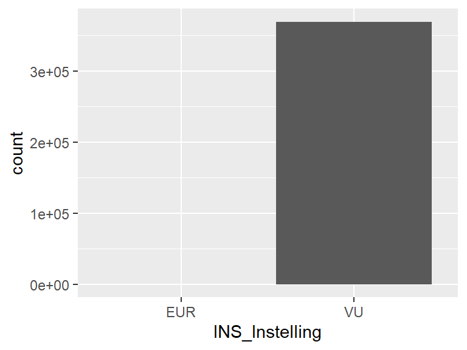

- Observed factor levels: "EUR", "VU".

## INS_Versie_1CHO_jaar

- The variable only takes one (non-missing) value: "2021". The variable contains 0 % missing observations.

## INS_Studentnummer

| Feature | Result |
| --- | --- |
| Variable type | numeric |
| Number of missing obs. | 0 (0 %) |
| Number of unique values | 121494 |
| Median | 2555116 |
| 1st and 3rd quartiles | 2129475; 2637204 |
| Min. and max. | 6777; 8545790 |

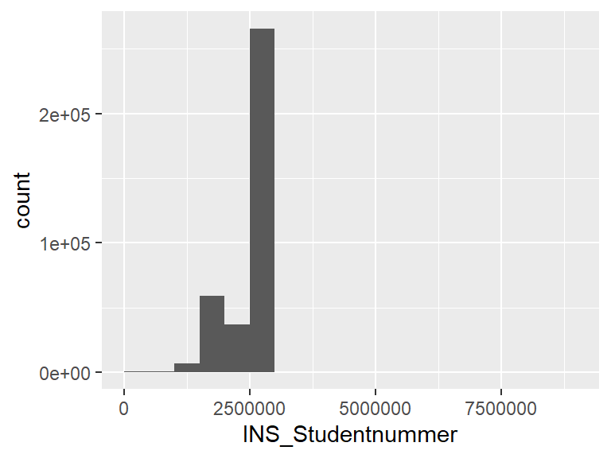

## INS_Inschrijvingsjaar

| Feature | Result |
| --- | --- |
| Variable type | numeric |
| Number of missing obs. | 0 (0 %) |
| Number of unique values | 13 |
| Median | 2016 |
| 1st and 3rd quartiles | 2013; 2020 |
| Min. and max. | 2010; 2022 |

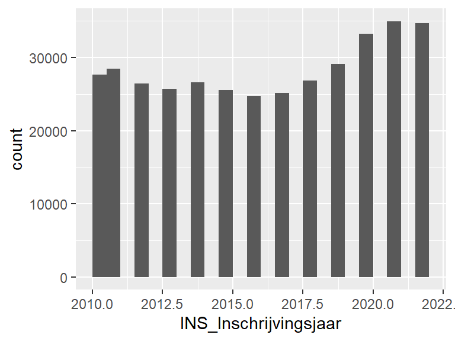

## INS_Inschrijvingsjaar_EOI

| Feature | Result |
| --- | --- |
| Variable type | numeric |
| Number of missing obs. | 2102 (0.57 %) |
| Number of unique values | 30 |
| Median | 2015 |
| 1st and 3rd quartiles | 2012; 2019 |
| Min. and max. | 1987; 2022 |

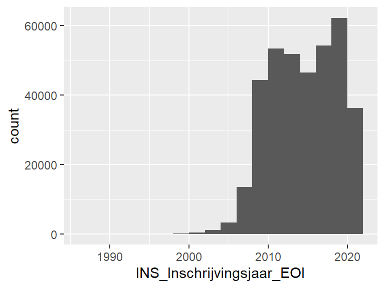

## INS_Studierichting_SAP_numeriek

| Feature | Result |
| --- | --- |
| Variable type | numeric |
| Number of missing obs. | 0 (0 %) |
| Number of unique values | 297 |
| Median | 50051118 |
| 1st and 3rd quartiles | 50046599; 50051769 |
| Min. and max. | 50043568; 52579738 |

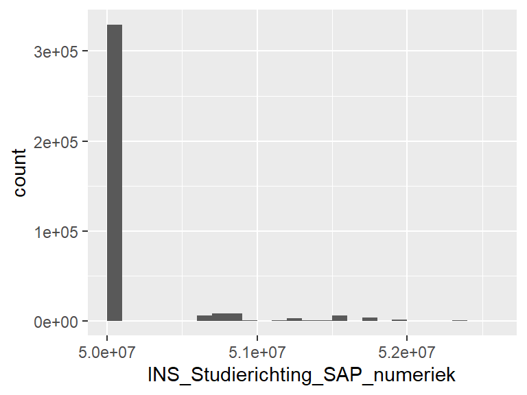

## INS_Soort_inschrijving_actuele_instelling

| Feature | Result |
| --- | --- |
| Variable type | numeric |
| Number of missing obs. | 0 (0 %) |
| Number of unique values | 4 |
| Median | 1 |
| 1st and 3rd quartiles | 1; 1 |
| Min. and max. | 1; 4 |

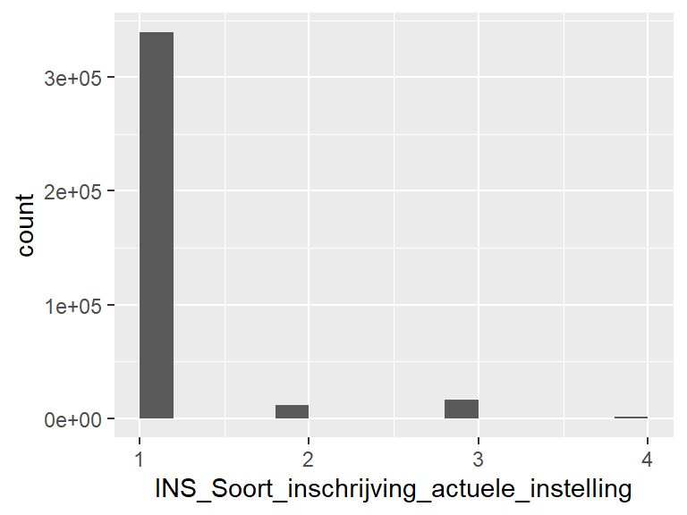

## INS_Opleidingsfase_actueel

| Feature | Result |
| --- | --- |
| Variable type | character |
| Number of missing obs. | 0 (0 %) |
| Number of unique values | 5 |
| Mode | “B” |

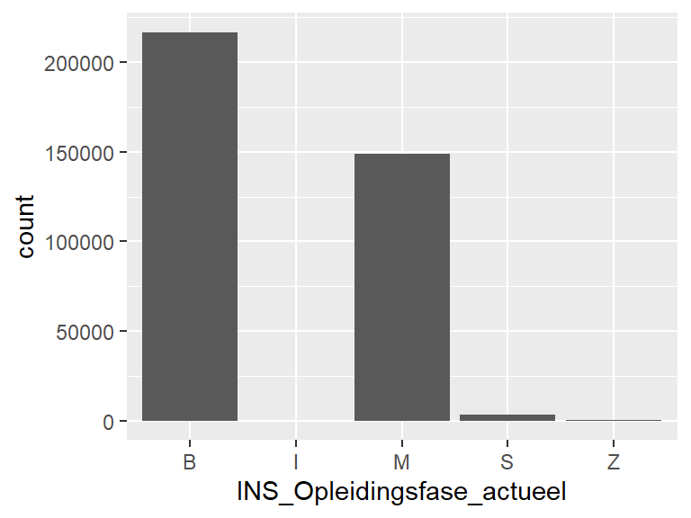

- Observed factor levels: "B", "I", "M", "S", "Z".

## INS_Indicatie_actief_op_peildatum

| Feature | Result |
| --- | --- |
| Variable type | numeric |
| Number of missing obs. | 0 (0 %) |
| Number of unique values | 4 |
| Median | 1 |
| 1st and 3rd quartiles | 1; 1 |
| Min. and max. | 1; 4 |

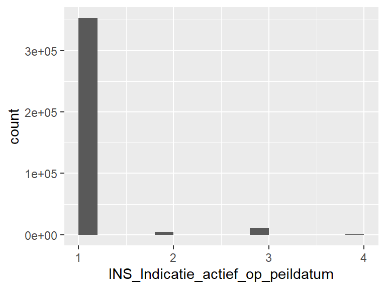

## INS_Opleidingscode_actueel

| Feature | Result |
| --- | --- |
| Variable type | numeric |
| Number of missing obs. | 0 (0 %) |
| Number of unique values | 214 |
| Median | 56856 |
| 1st and 3rd quartiles | 50952; 60644 |
| Min. and max. | 6551; 69333 |

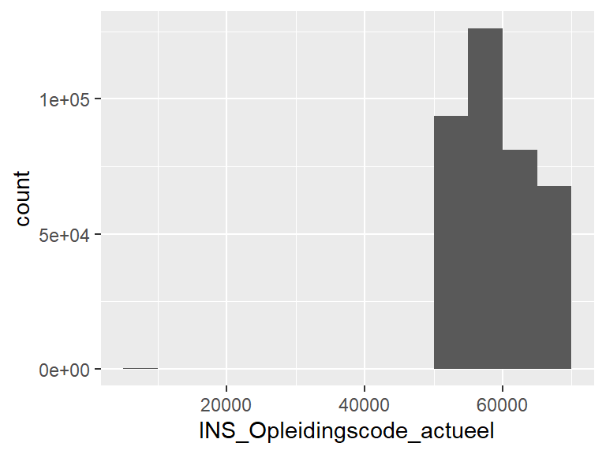

## INS_Opleidingsnaam_2002

| Feature | Result |
| --- | --- |
| Variable type | character |
| Number of missing obs. | 0 (0 %) |
| Number of unique values | 211 |
| Mode | “B Rechtsgeleerdheid” |

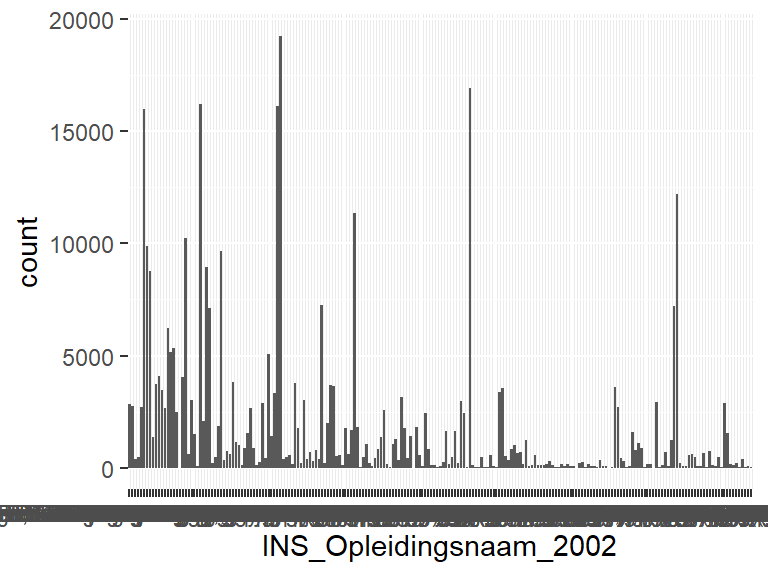

- Observed factor levels: "B Aarde, Economie en Duurzaamheid", "B Aardwetenschappen", "B Algemene Cultuurwetenschappen", "B Archeologie", "B Artificial Intelligence", …, "M Tinbergen Institute Research Master in Economics (joint degree)", "M TRANSPORT AND SUPPLY CHAIN MANAGEMENT", "M Visual Arts, Media and Architecture (research)", "M Wijsbegeerte", "M Wijsbegeerte van een Bepaald Wetenschapsgebied" (201 values omitted).

## INS_Indicatie_eerste_jaars_opleiding

| Feature | Result |
| --- | --- |
| Variable type | numeric |
| Number of missing obs. | 0 (0 %) |
| Number of unique values | 5 |
| Median | 2 |
| 1st and 3rd quartiles | 1; 2 |
| Min. and max. | 1; 5 |

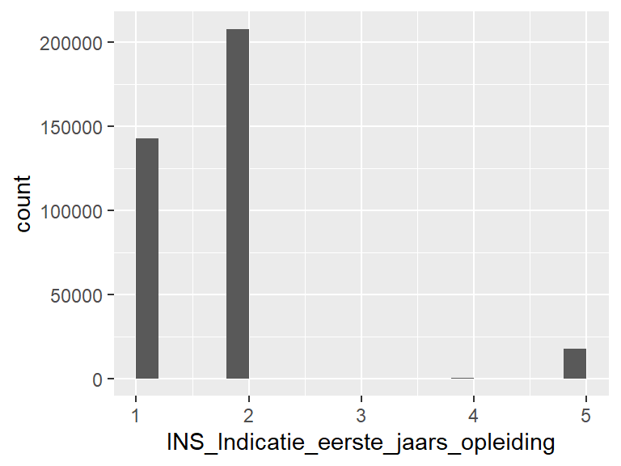

## INS_Indicatie_eerste_jaars_instelling

| Feature | Result |
| --- | --- |
| Variable type | numeric |
| Number of missing obs. | 0 (0 %) |
| Number of unique values | 5 |
| Median | 2 |
| 1st and 3rd quartiles | 1; 2 |
| Min. and max. | 1; 5 |

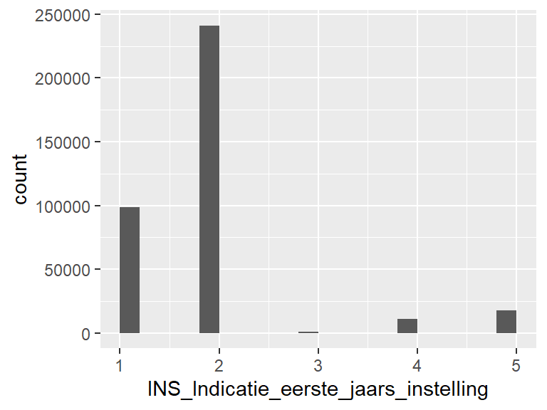

## INS_Indicatie_eerste_jaars_opleiding_en_instelling

| Feature | Result |
| --- | --- |
| Variable type | numeric |
| Number of missing obs. | 0 (0 %) |
| Number of unique values | 3 |
| Median | 2 |
| 1st and 3rd quartiles | 1; 2 |
| Min. and max. | 1; 5 |

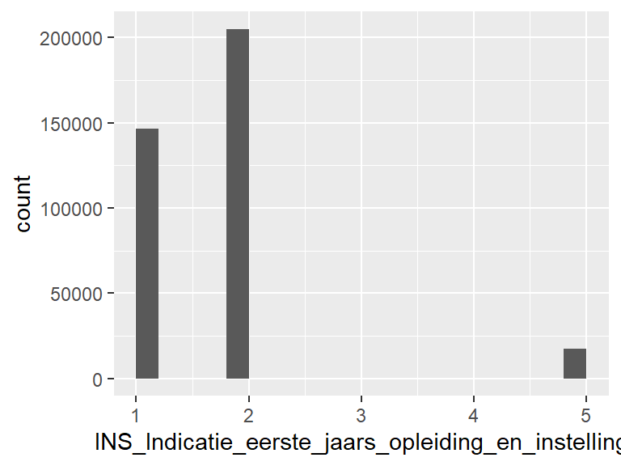

## INS_Eerste_jaar_opleiding_en_instelling

| Feature | Result |
| --- | --- |
| Variable type | numeric |
| Number of missing obs. | 0 (0 %) |
| Number of unique values | 40 |
| Median | 2015 |
| 1st and 3rd quartiles | 2012; 2019 |
| Min. and max. | 1982; 2022 |

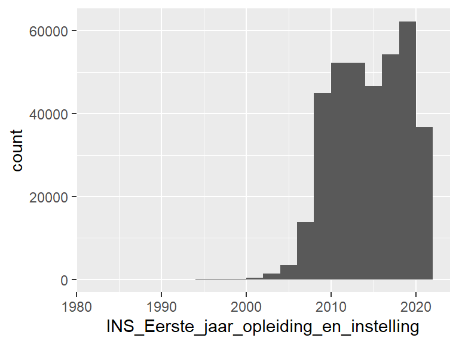

## INS_Eerste_jaar_hoger_onderwijs

| Feature | Result |
| --- | --- |
| Variable type | numeric |
| Number of missing obs. | 0 (0 %) |
| Number of unique values | 53 |
| Median | 2013 |
| 1st and 3rd quartiles | 2009; 2017 |
| Min. and max. | 1964; 2022 |

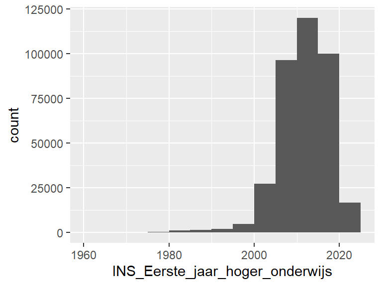

## INS_Eerste_jaar_soort_hoger_onderwijs

| Feature | Result |
| --- | --- |
| Variable type | numeric |
| Number of missing obs. | 0 (0 %) |
| Number of unique values | 53 |
| Median | 2013 |
| 1st and 3rd quartiles | 2010; 2017 |
| Min. and max. | 1964; 2022 |

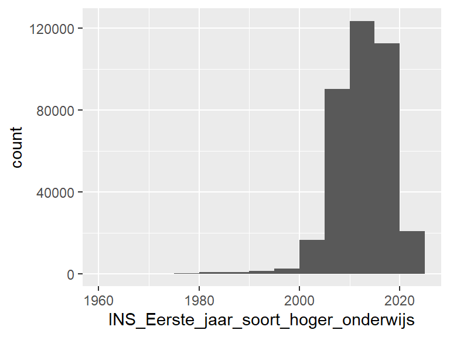

## INS_Vooropleiding_voor_HO_code

| Feature | Result |
| --- | --- |
| Variable type | numeric |
| Number of missing obs. | 0 (0 %) |
| Number of unique values | 46 |
| Median | 405 |
| 1st and 3rd quartiles | 402; 411 |
| Min. and max. | 0; 506 |

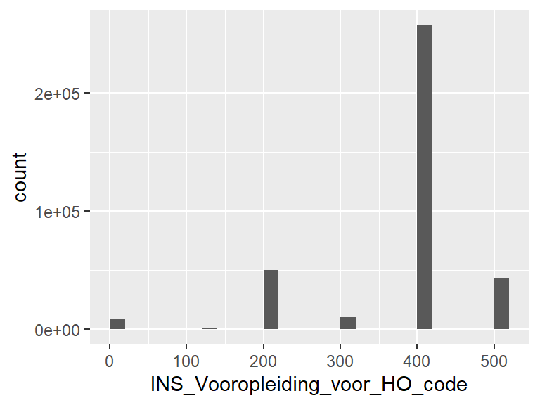

## INS_Vooropleiding_voor_HO_jaar

| Feature | Result |
| --- | --- |
| Variable type | numeric |
| Number of missing obs. | 9186 (2.49 %) |
| Number of unique values | 63 |
| Median | 2011 |
| 1st and 3rd quartiles | 2008; 2015 |
| Min. and max. | 1953; 2021 |

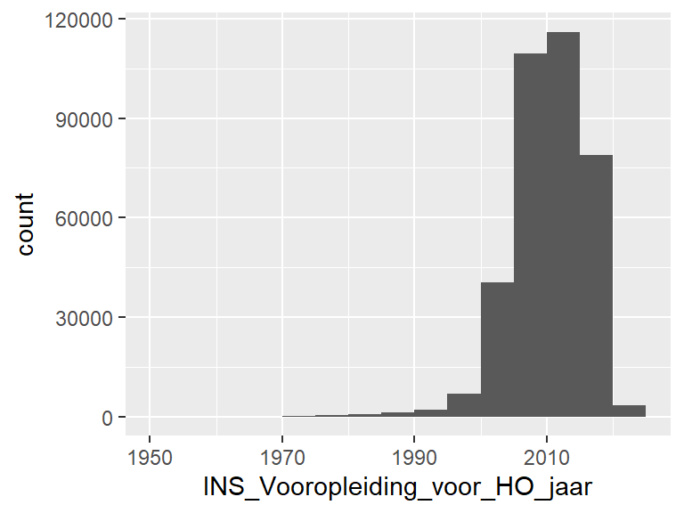

## INS_Vooropleiding_voor_HO_BRIN

| Feature | Result |
| --- | --- |
| Variable type | character |
| Number of missing obs. | 60161 (16.3 %) |
| Number of unique values | 666 |
| Mode | “25PZ” |

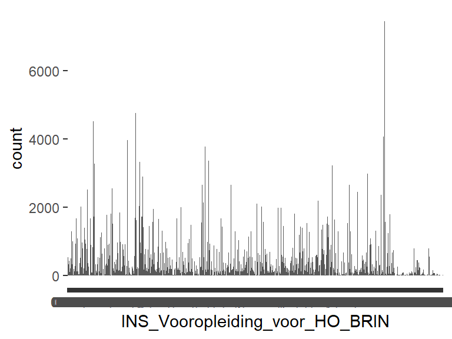

- Observed factor levels: "00AH", "00AQ", "00BD", "00CB", "00DI", …, "31KX", "31LV", "31LW", "31MD", "31RY" (656 values omitted).

## INS_Vooropleiding_binnen_HO_code

| Feature | Result |
| --- | --- |
| Variable type | numeric |
| Number of missing obs. | 0 (0 %) |
| Number of unique values | 70 |
| Median | 0 |
| 1st and 3rd quartiles | 0; 903 |
| Min. and max. | 0; 1355 |

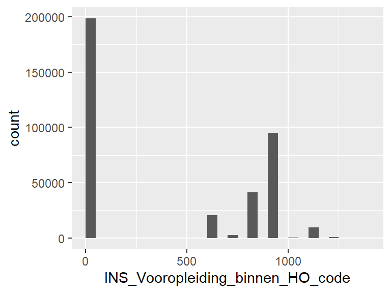

## INS_Vooropleiding_binnen_HO_jaar

| Feature | Result |
| --- | --- |
| Variable type | numeric |
| Number of missing obs. | 198646 (53.82 %) |
| Number of unique values | 52 |
| Median | 2013 |
| 1st and 3rd quartiles | 2010; 2017 |
| Min. and max. | 1967; 2021 |

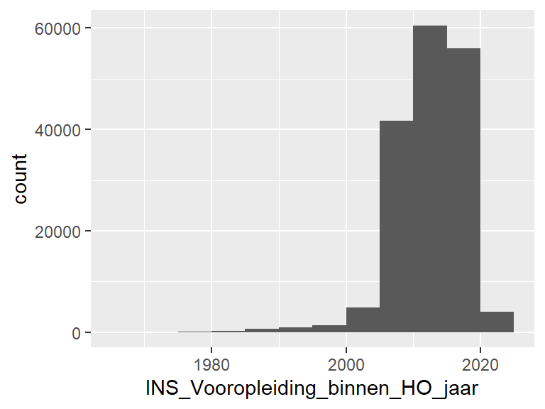

## INS_Vooropleiding_binnen_HO_BRIN

| Feature | Result |
| --- | --- |
| Variable type | character |
| Number of missing obs. | 202021 (54.73 %) |
| Number of unique values | 140 |
| Mode | “21PL” |

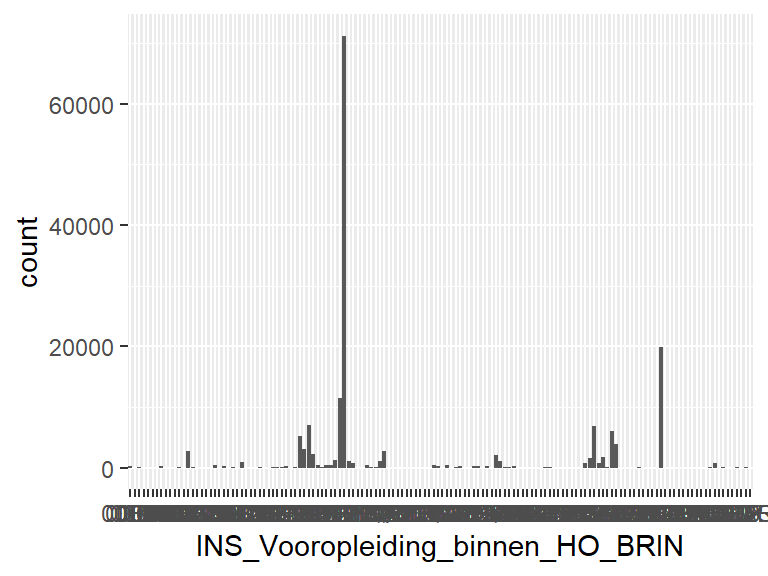

- Observed factor levels: "00BH", "00BM", "00DV", "00EY", "00IC", …, "30PB", "30TX", "30WG", "31FR", "31PT" (130 values omitted).

## INS_Hoogste_vooropleiding_code_1CHO

| Feature | Result |
| --- | --- |
| Variable type | numeric |
| Number of missing obs. | 0 (0 %) |
| Number of unique values | 104 |
| Median | 502 |
| 1st and 3rd quartiles | 405; 903 |
| Min. and max. | 0; 1355 |

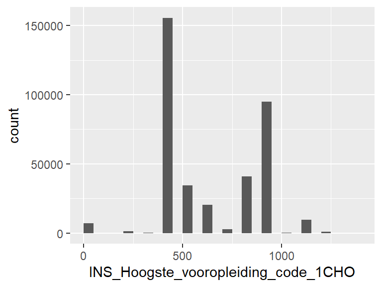

## INS_Hoogste_vooropleiding_jaar_1CHO

| Feature | Result |
| --- | --- |
| Variable type | numeric |
| Number of missing obs. | 7151 (1.94 %) |
| Number of unique values | 58 |
| Median | 2013 |
| 1st and 3rd quartiles | 2010; 2017 |
| Min. and max. | 1963; 2021 |

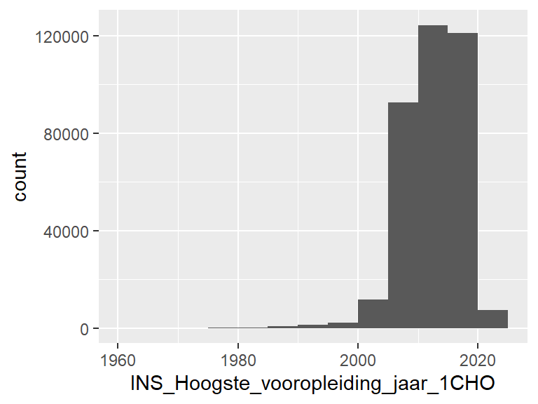

## INS_Hoogste_vooropleiding_BRIN_1CHO

| Feature | Result |
| --- | --- |
| Variable type | character |
| Number of missing obs. | 46809 (12.68 %) |
| Number of unique values | 734 |
| Mode | “21PL” |

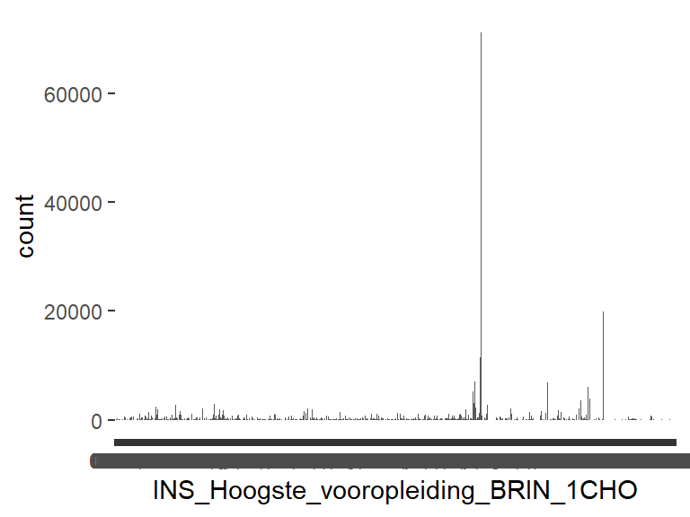

- Observed factor levels: "00AH", "00AQ", "00BD", "00BH", "00BM", …, "31LV", "31LW", "31MD", "31PT", "31RY" (724 values omitted).

## INS_Verblijfsjaren_hoger_onderwijs

| Feature | Result |
| --- | --- |
| Variable type | integer |
| Number of missing obs. | 16147 (4.37 %) |
| Number of unique values | 39 |
| Median | 4 |
| 1st and 3rd quartiles | 2; 6 |
| Min. and max. | 1; 39 |

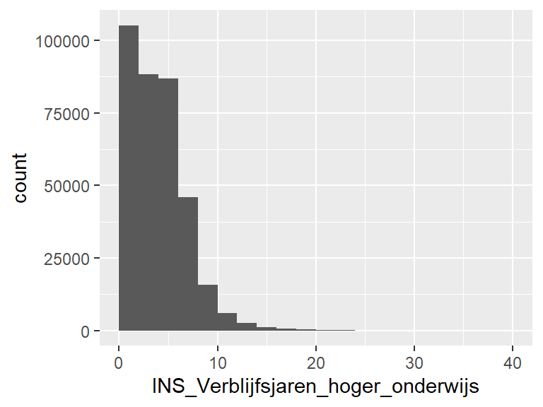

## INS_Verblijfsjaren_wetenschappelijk_onderwijs

| Feature | Result |
| --- | --- |
| Variable type | integer |
| Number of missing obs. | 16147 (4.37 %) |
| Number of unique values | 39 |
| Median | 3 |
| 1st and 3rd quartiles | 2; 5 |
| Min. and max. | 1; 39 |

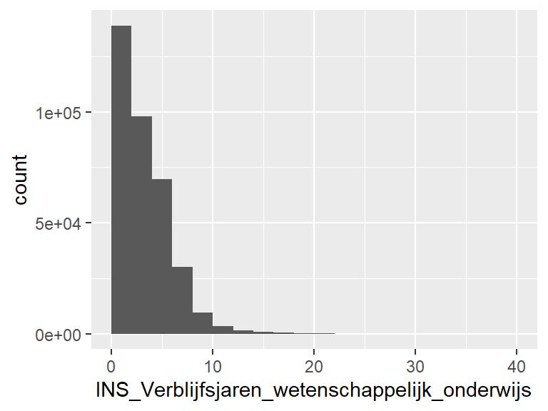

## INS_Inclusief_UvA

| Feature | Result |
| --- | --- |
| Variable type | logical |
| Number of missing obs. | 0 (0 %) |
| Number of unique values | 2 |
| Mode | “FALSE” |

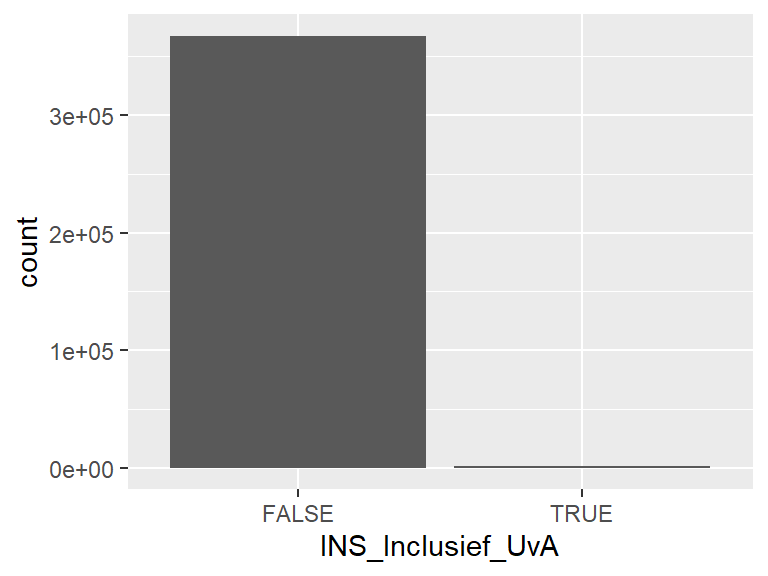

## INS_Premaster

- The variable only takes one (non-missing) value: "P". The variable contains 96.12 % missing observations.

## INS_Hoogste_vooropleiding_binnen_HO_code

| Feature | Result |
| --- | --- |
| Variable type | integer |
| Number of missing obs. | 198646 (53.82 %) |
| Number of unique values | 1310 |
| Median | 50700 |
| 1st and 3rd quartiles | 34579; 56604 |
| Min. and max. | 520; 81000 |

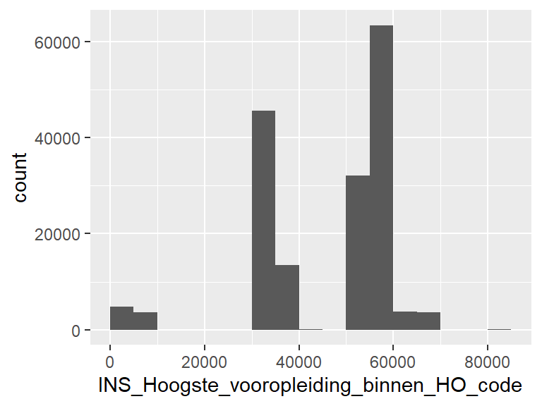

## INS_Faculteit

| Feature | Result |
| --- | --- |
| Variable type | character |
| Number of missing obs. | 0 (0 %) |
| Number of unique values | 10 |
| Mode | “BETA” |

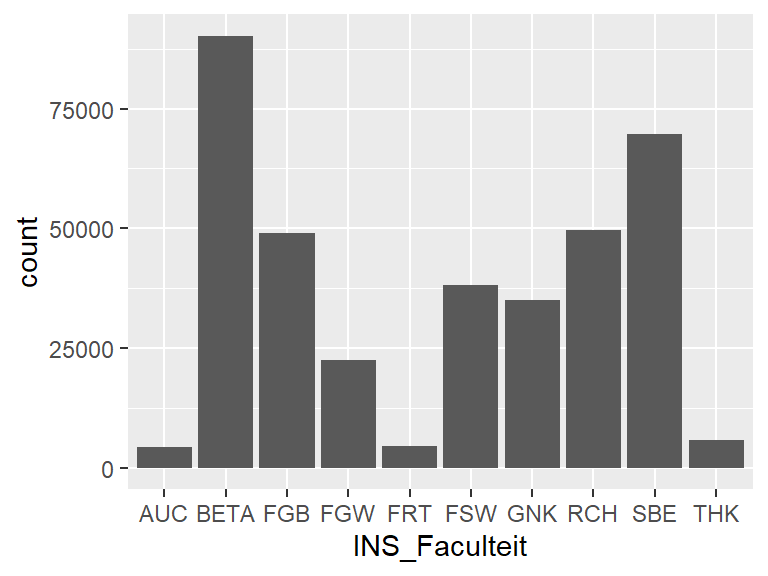

- Observed factor levels: "AUC", "BETA", "FGB", "FGW", "FRT", "FSW", "GNK", "RCH", "SBE", "THK".

## INS_Opleidingsvorm

| Feature | Result |
| --- | --- |
| Variable type | numeric |
| Number of missing obs. | 0 (0 %) |
| Number of unique values | 3 |
| Median | 1 |
| 1st and 3rd quartiles | 1; 1 |
| Min. and max. | 1; 3 |

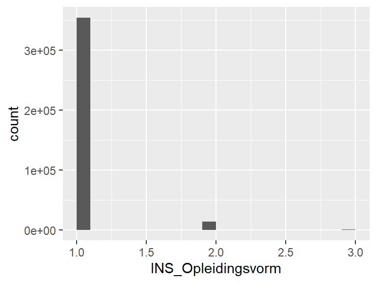

## INS_Code_bekostiging

| Feature | Result |
| --- | --- |
| Variable type | character |
| Number of missing obs. | 0 (0 %) |
| Number of unique values | 4 |
| Mode | “J” |

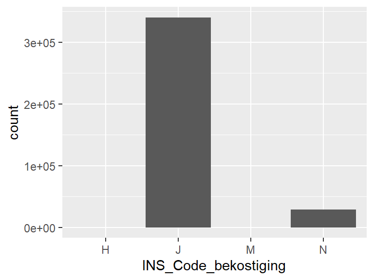

- Observed factor levels: "H", "J", "M", "N".

## INS_Code_examenresultaat

| Feature | Result |
| --- | --- |
| Variable type | numeric |
| Number of missing obs. | 279049 (75.6 %) |
| Number of unique values | 3 |
| Median | 1 |
| 1st and 3rd quartiles | 1; 1 |
| Min. and max. | 1; 9 |

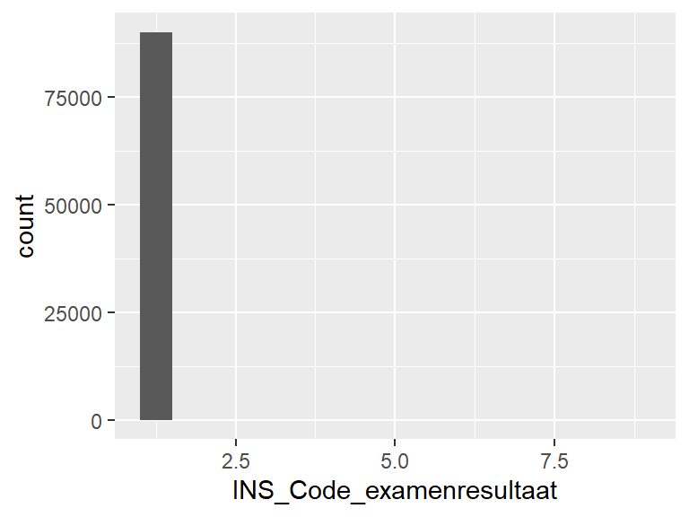

## INS_Opleidingscode_CROHO

| Feature | Result |
| --- | --- |
| Variable type | numeric |
| Number of missing obs. | 5867 (1.59 %) |
| Number of unique values | 7 |
| Median | 6 |
| 1st and 3rd quartiles | 5; 8 |
| Min. and max. | 1; 9 |

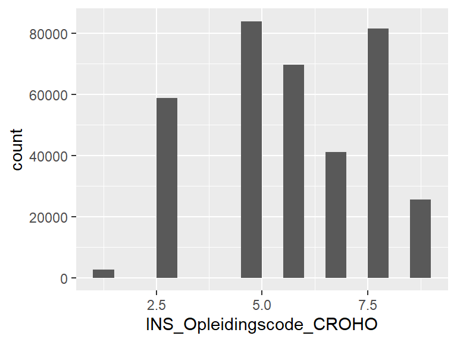

## INS_Code_beeindiging_inschrijving

| Feature | Result |
| --- | --- |
| Variable type | numeric |
| Number of missing obs. | 0 (0 %) |
| Number of unique values | 4 |
| Median | 0 |
| 1st and 3rd quartiles | 0; 0 |
| Min. and max. | 0; 9 |

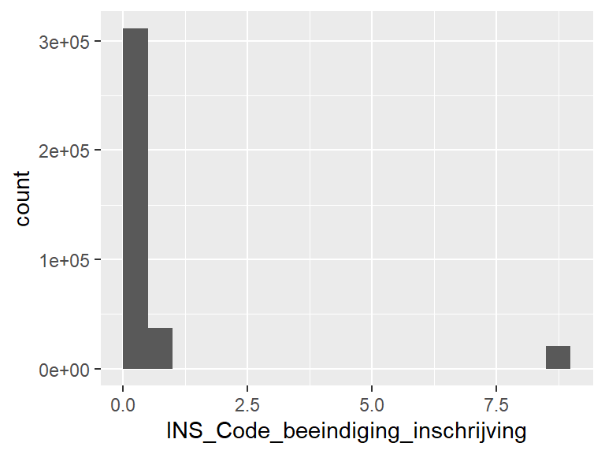

## INS_Type_onderwijs

| Feature | Result |
| --- | --- |
| Variable type | character |
| Number of missing obs. | 0 (0 %) |
| Number of unique values | 4 |
| Mode | “ba” |

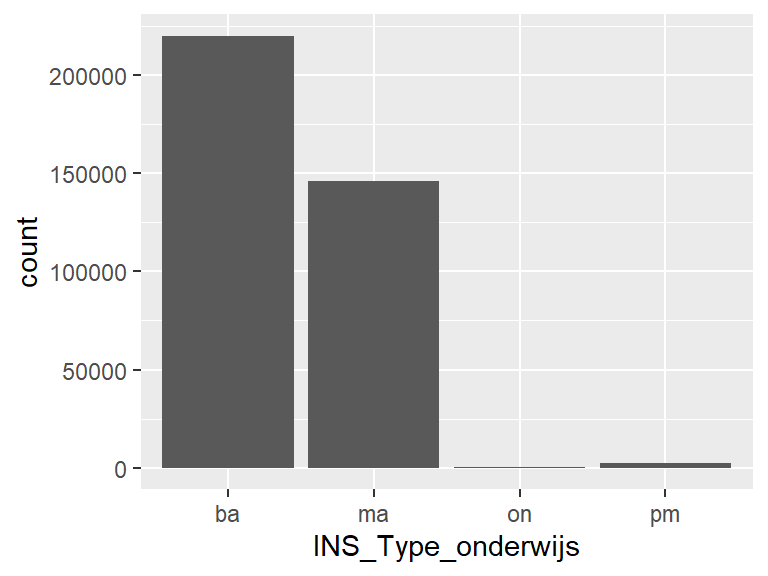

- Observed factor levels: "ba", "ma", "on", "pm".

## INS_Diplomajaar

| Feature | Result |
| --- | --- |
| Variable type | numeric |
| Number of missing obs. | 279049 (75.6 %) |
| Number of unique values | 14 |
| Median | 2016 |
| 1st and 3rd quartiles | 2013; 2019 |
| Min. and max. | 2009; 2022 |

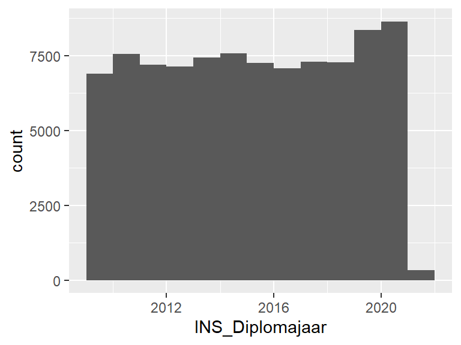

## INS_Diploma_opleidingsfase

| Feature | Result |
| --- | --- |
| Variable type | character |
| Number of missing obs. | 279049 (75.6 %) |
| Number of unique values | 4 |
| Mode | “M” |

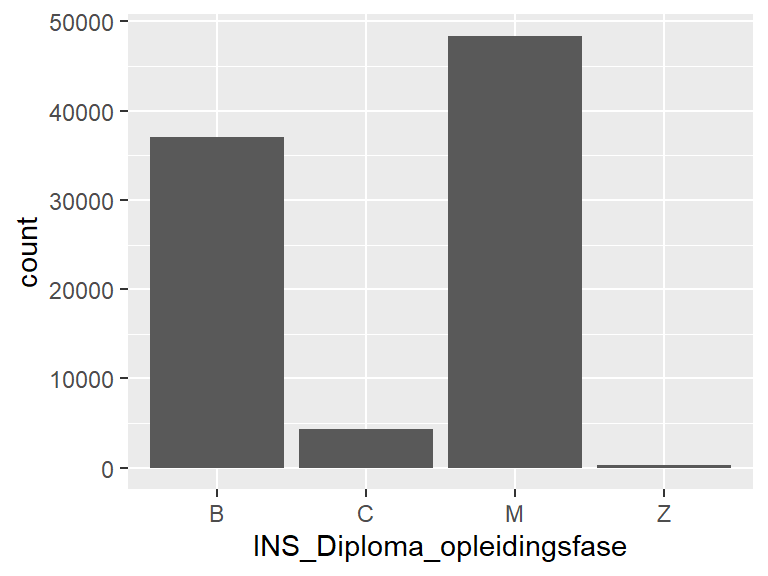

- Observed factor levels: "B", "C", "M", "Z".

## INS_Diploma_eerste

| Feature | Result |
| --- | --- |
| Variable type | numeric |
| Number of missing obs. | 279049 (75.6 %) |
| Number of unique values | 2 |
| Median | 2 |
| 1st and 3rd quartiles | 1; 2 |
| Min. and max. | 1; 2 |

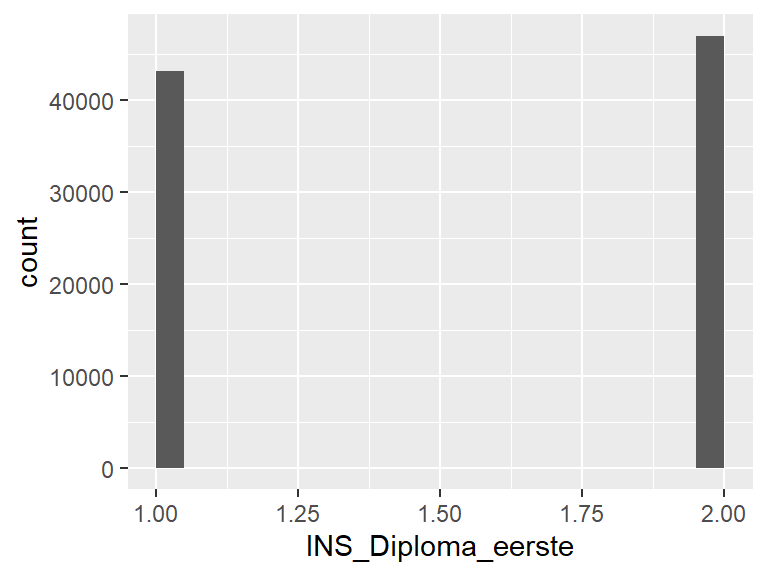

## INS_Diploma_eerste_in_categorie

| Feature | Result |
| --- | --- |
| Variable type | numeric |
| Number of missing obs. | 279049 (75.6 %) |
| Number of unique values | 6 |
| Median | 5 |
| 1st and 3rd quartiles | 3; 5 |
| Min. and max. | 3; 10 |

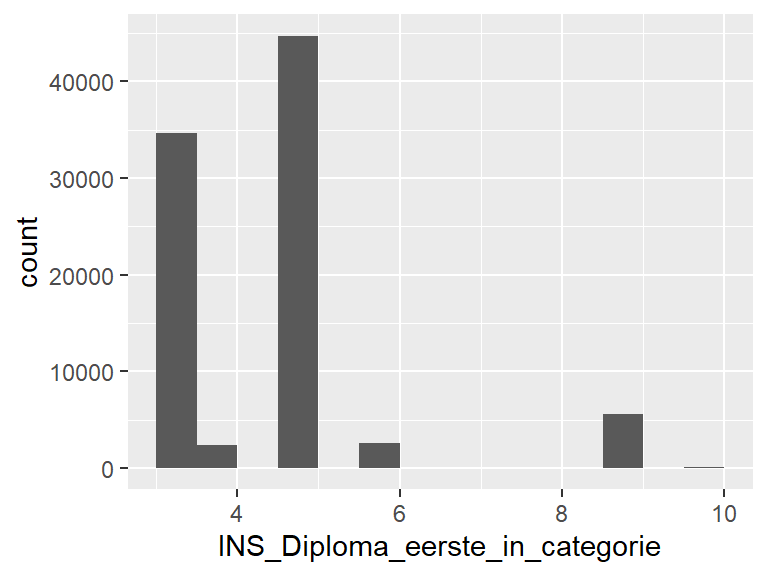

## INS_Diploma_eerste_in_categorie_hoofd_neven

| Feature | Result |
| --- | --- |
| Variable type | numeric |
| Number of missing obs. | 279049 (75.6 %) |
| Number of unique values | 6 |
| Median | 5 |
| 1st and 3rd quartiles | 3; 5 |
| Min. and max. | 3; 10 |

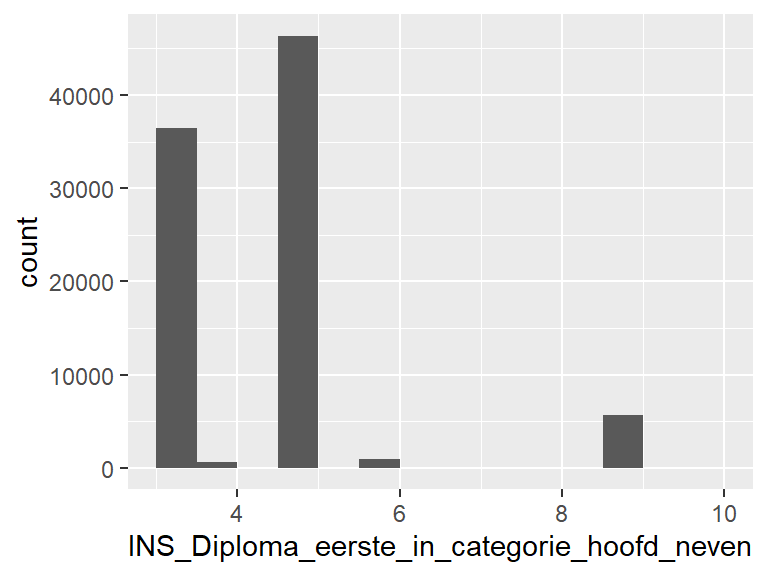

## INS_Diploma_eerste_bij_instelling_hoofd_neven

| Feature | Result |
| --- | --- |
| Variable type | numeric |
| Number of missing obs. | 279049 (75.6 %) |
| Number of unique values | 6 |
| Median | 5 |
| 1st and 3rd quartiles | 3; 5 |
| Min. and max. | 3; 10 |

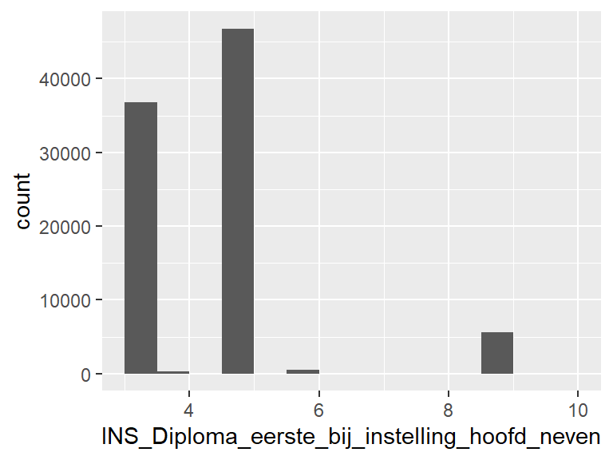

## DEM_Geslacht

| Feature | Result |
| --- | --- |
| Variable type | character |
| Number of missing obs. | 0 (0 %) |
| Number of unique values | 3 |
| Mode | “V” |

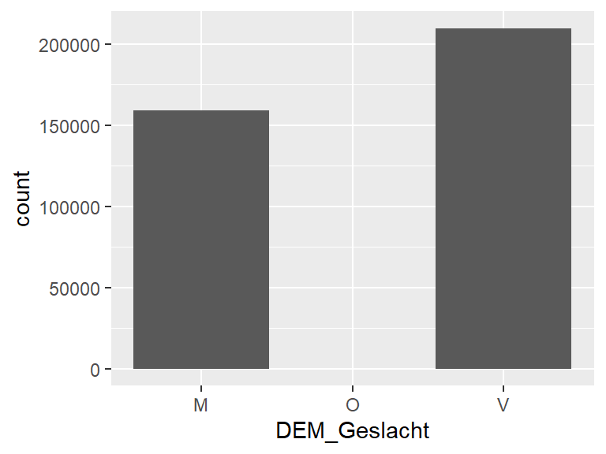

- Observed factor levels: "M", "O", "V".

## DEM_Leeftijd_peildatum_1_oktober

| Feature | Result |
| --- | --- |
| Variable type | numeric |
| Number of missing obs. | 0 (0 %) |
| Number of unique values | 66 |
| Median | 22 |
| 1st and 3rd quartiles | 20; 25 |
| Min. and max. | 15; 81 |

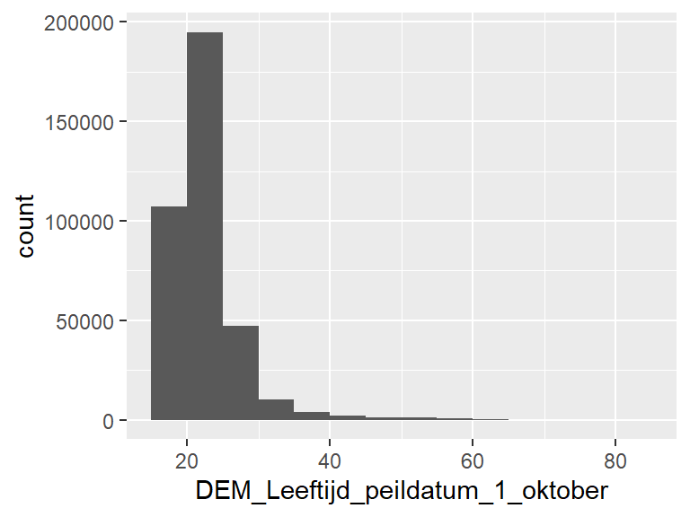

## DEM_Leeftijd_peildatum_1_jan

| Feature | Result |
| --- | --- |
| Variable type | numeric |
| Number of missing obs. | 0 (0 %) |
| Number of unique values | 67 |
| Median | 23 |
| 1st and 3rd quartiles | 20; 25 |
| Min. and max. | 15; 81 |

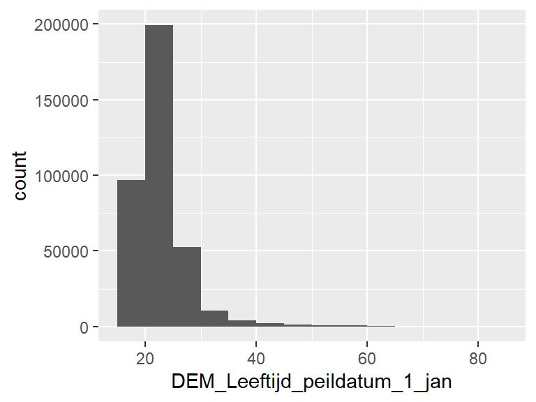

## DEM_Nationaliteit_1

| Feature | Result |
| --- | --- |
| Variable type | numeric |
| Number of missing obs. | 152 (0.04 %) |
| Number of unique values | 149 |
| Median | 1 |
| 1st and 3rd quartiles | 1; 1 |
| Min. and max. | 1; 499 |

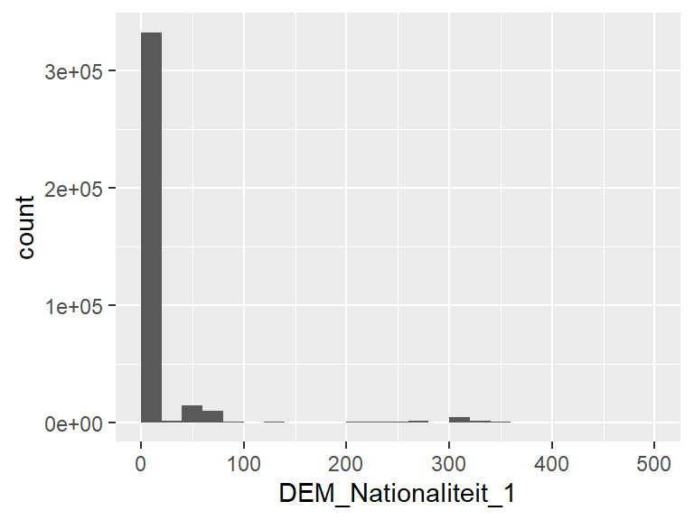

## DEM_Nationaliteit_2

| Feature | Result |
| --- | --- |
| Variable type | numeric |
| Number of missing obs. | 313866 (85.03 %) |
| Number of unique values | 159 |
| Median | 131 |
| 1st and 3rd quartiles | 112; 331 |
| Min. and max. | 27; 499 |

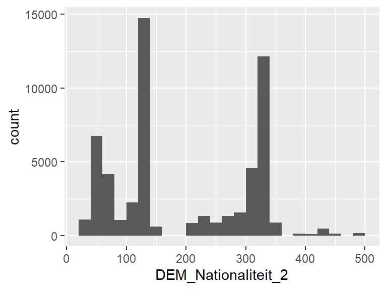

## DEM_Nationaliteit_3

| Feature | Result |
| --- | --- |
| Variable type | integer |
| Number of missing obs. | 368395 (99.8 %) |
| Number of unique values | 59 |
| Median | 307 |
| 1st and 3rd quartiles | 131; 339 |
| Min. and max. | 29; 500 |

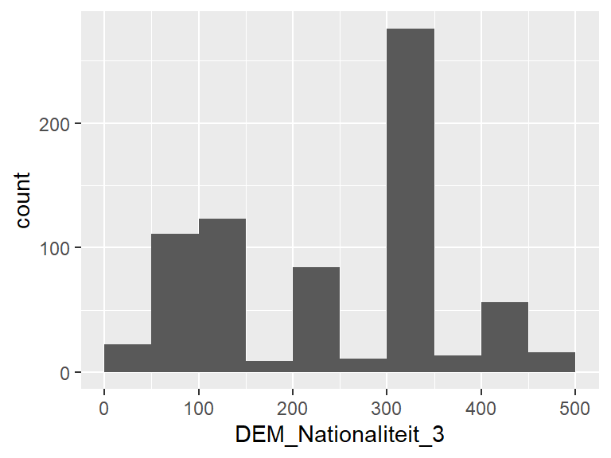

## INS_Postcode_student_1okt_peildatum

| Feature | Result |
| --- | --- |
| Variable type | integer |
| Number of missing obs. | 2032 (0.55 %) |
| Number of unique values | 2904 |
| Median | 1183 |
| 1st and 3rd quartiles | 1072; 2312 |
| Min. and max. | 10; 9988 |

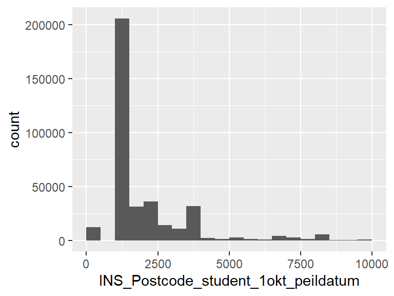

## INS_Vooropleiding_voor_HO_gem_cijfer

| Feature | Result |
| --- | --- |
| Variable type | numeric |
| Number of missing obs. | 100725 (27.29 %) |
| Number of unique values | 38 |
| Median | 66 |
| 1st and 3rd quartiles | 64; 70 |
| Min. and max. | 57; 95 |

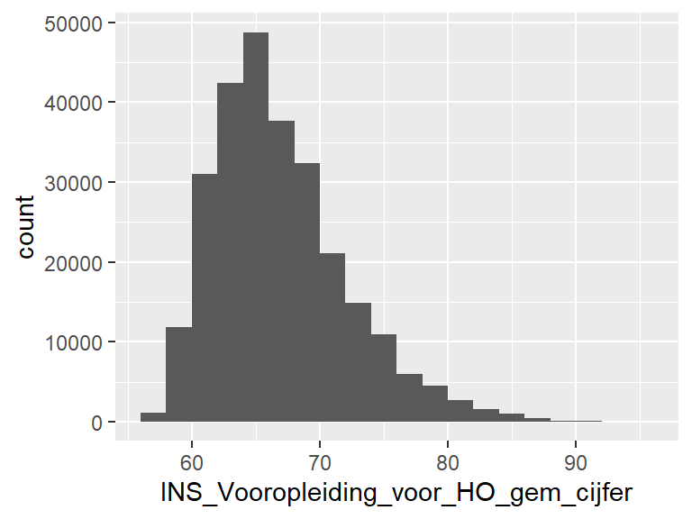

## INS_Datum_inschrijving

| Feature | Result |
| --- | --- |
| Variable type | Date |
| Number of missing obs. | 0 (0 %) |
| Number of unique values | 150 |
| Mode | “2022-09-01” |
| Min. and max. | 2010-09-01; 2023-02-01 |
| 1st and 3rd quartiles | 2013-09-01; 2020-09-01 |

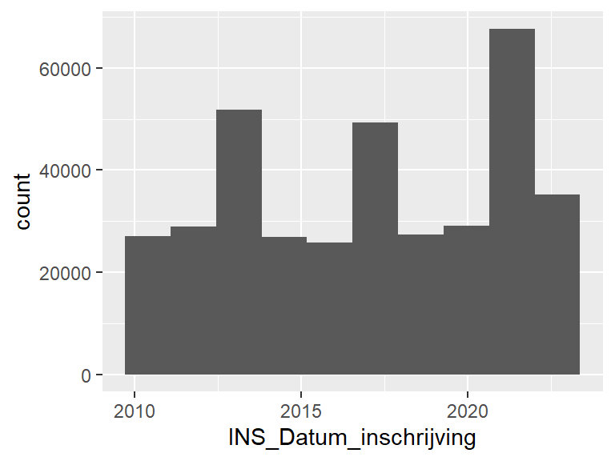

## INS_Datum_uitschrijving

| Feature | Result |
| --- | --- |
| Variable type | Date |
| Number of missing obs. | 0 (0 %) |
| Number of unique values | 180 |
| Mode | “2023-08-31” |
| Min. and max. | 2010-09-30; 2023-08-31 |
| 1st and 3rd quartiles | 2014-08-31; 2021-08-31 |

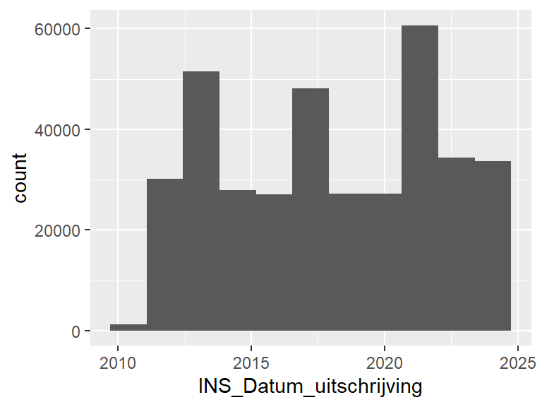

## INS_Verblijfsjaar_type_onderwijs_binnen_HO

| Feature | Result |
| --- | --- |
| Variable type | numeric |
| Number of missing obs. | 16147 (4.37 %) |
| Number of unique values | 26 |
| Median | 2 |
| 1st and 3rd quartiles | 1; 4 |
| Min. and max. | 1; 26 |

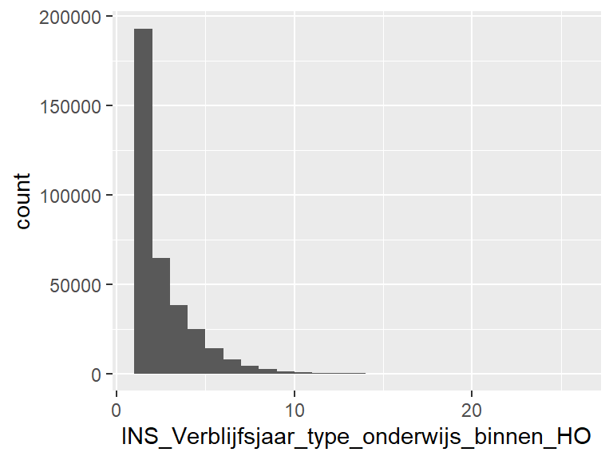

## INS_Postcode_student_voor_HO

| Feature | Result |
| --- | --- |
| Variable type | integer |
| Number of missing obs. | 67520 (18.29 %) |
| Number of unique values | 3304 |
| Median | 2135 |
| 1st and 3rd quartiles | 1382; 3823 |
| Min. and max. | 10; 9997 |

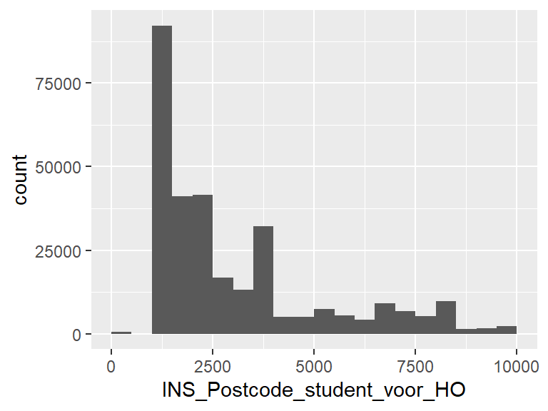

## INS_Maand_inschrijving_van

| Feature | Result |
| --- | --- |
| Variable type | numeric |
| Number of missing obs. | 0 (0 %) |
| Number of unique values | 12 |
| Median | 9 |
| 1st and 3rd quartiles | 9; 9 |
| Min. and max. | 1; 12 |

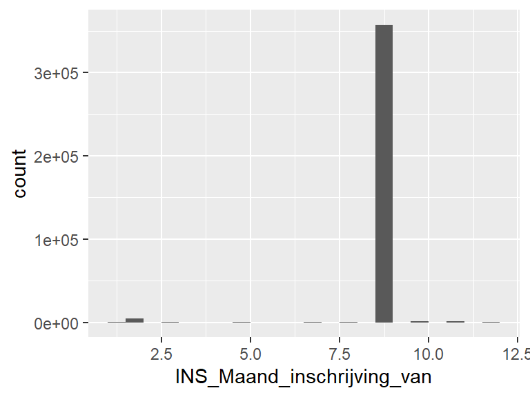

## INS_Maand_inschrijving_tot

| Feature | Result |
| --- | --- |
| Variable type | numeric |
| Number of missing obs. | 328152 (88.9 %) |
| Number of unique values | 12 |
| Median | 4 |
| 1st and 3rd quartiles | 2; 10 |
| Min. and max. | 1; 13 |

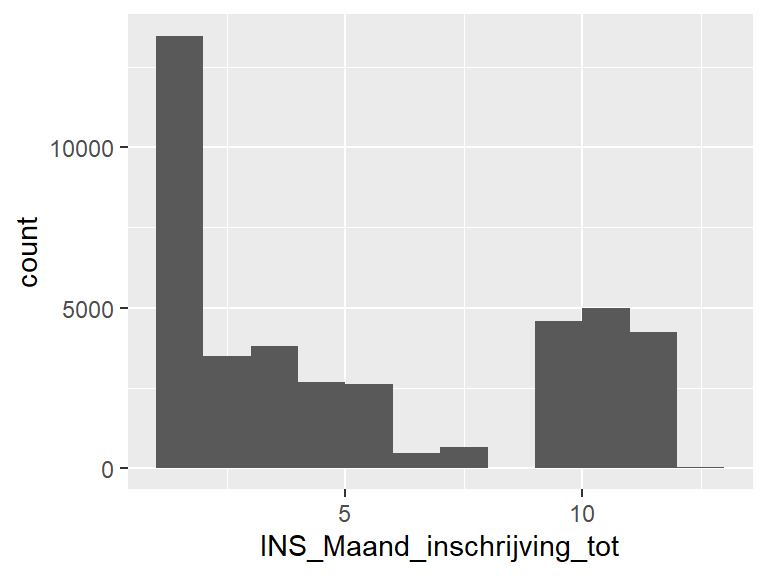

## INS_Maand_examenresultaat

| Feature | Result |
| --- | --- |
| Variable type | numeric |
| Number of missing obs. | 279049 (75.6 %) |
| Number of unique values | 12 |
| Median | 7 |
| 1st and 3rd quartiles | 6; 8 |
| Min. and max. | 1; 12 |

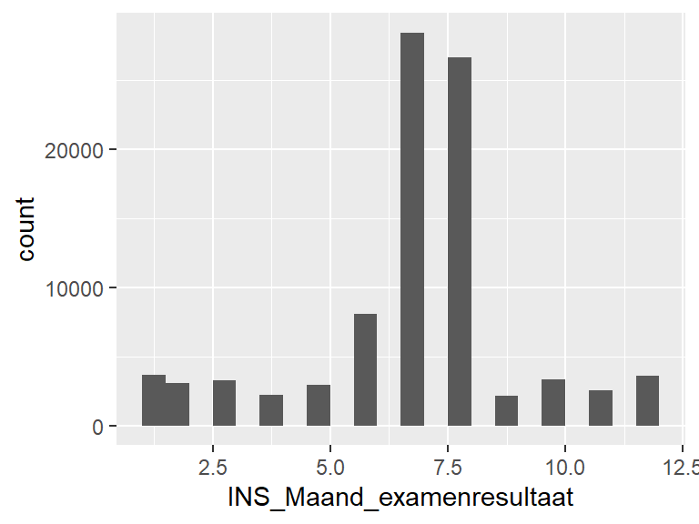

## INS_Croho_sub_onderdeel

| Feature | Result |
| --- | --- |
| Variable type | numeric |
| Number of missing obs. | 23 (0.01 %) |
| Number of unique values | 8 |
| Median | 9 |
| 1st and 3rd quartiles | 8; 11 |
| Min. and max. | 2; 20 |

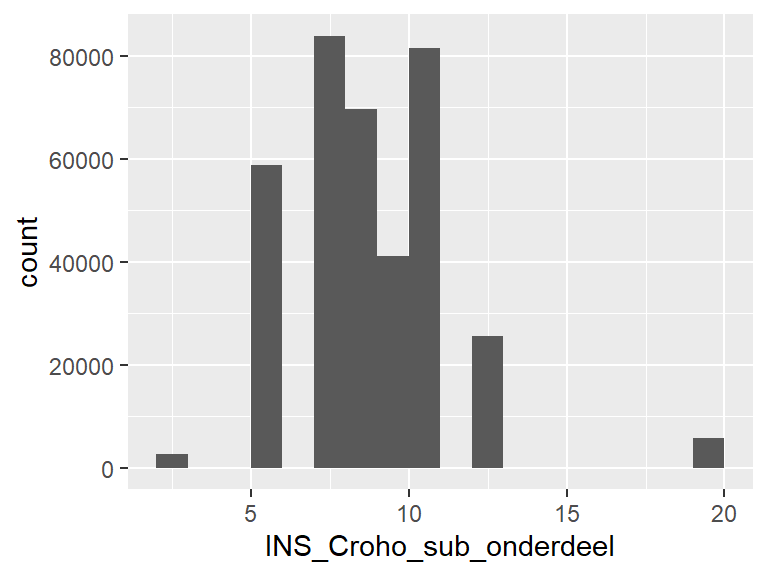

## INS_Verblijfsjaar_type_onderwijs

| Feature | Result |
| --- | --- |
| Variable type | numeric |
| Number of missing obs. | 16147 (4.37 %) |
| Number of unique values | 22 |
| Median | 2 |
| 1st and 3rd quartiles | 1; 3 |
| Min. and max. | 1; 22 |

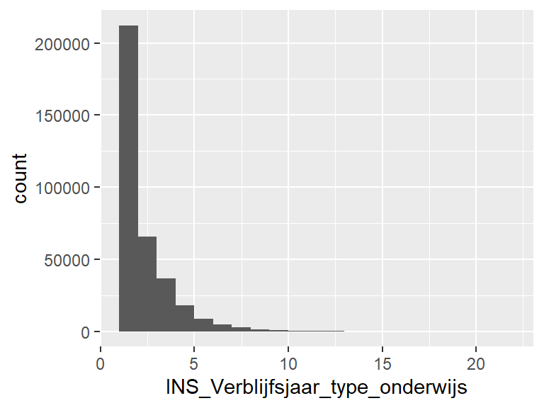

## DEM_Nationaliteit_EER_naam

| Feature | Result |
| --- | --- |
| Variable type | character |
| Number of missing obs. | 0 (0 %) |
| Number of unique values | 3 |
| Mode | “NL” |

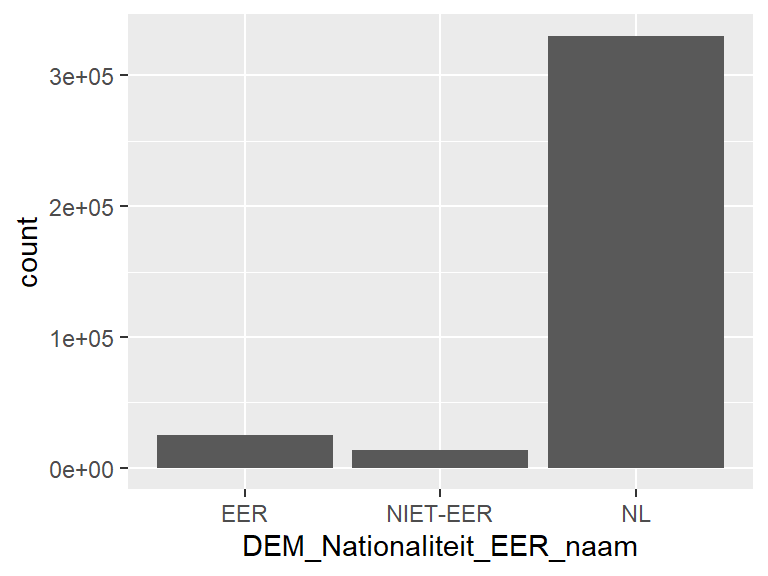

- Observed factor levels: "EER", "NIET-EER", "NL".

## DEM_Indicatie_nationaliteit_EER_actueel

| Feature | Result |
| --- | --- |
| Variable type | logical |
| Number of missing obs. | 0 (0 %) |
| Number of unique values | 2 |
| Mode | “FALSE” |

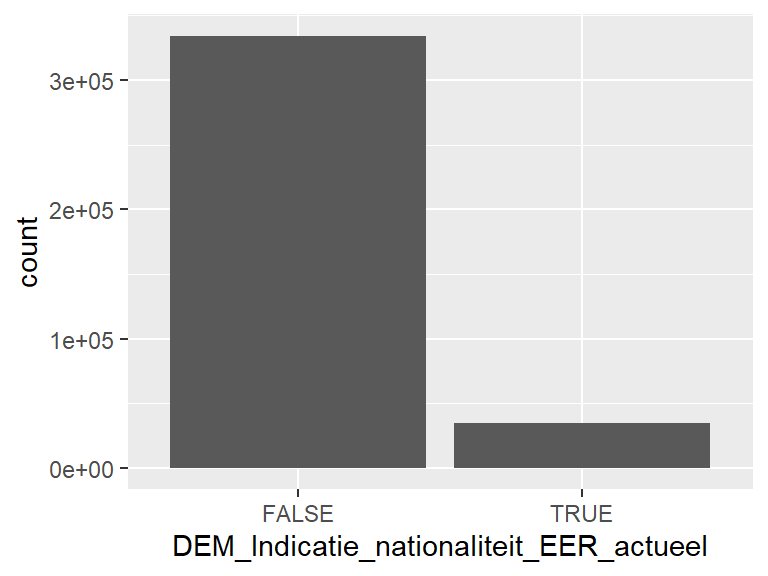

## DEM_Indicatie_nationaliteit_EER_peildatum

| Feature | Result |
| --- | --- |
| Variable type | logical |
| Number of missing obs. | 0 (0 %) |
| Number of unique values | 2 |
| Mode | “TRUE” |

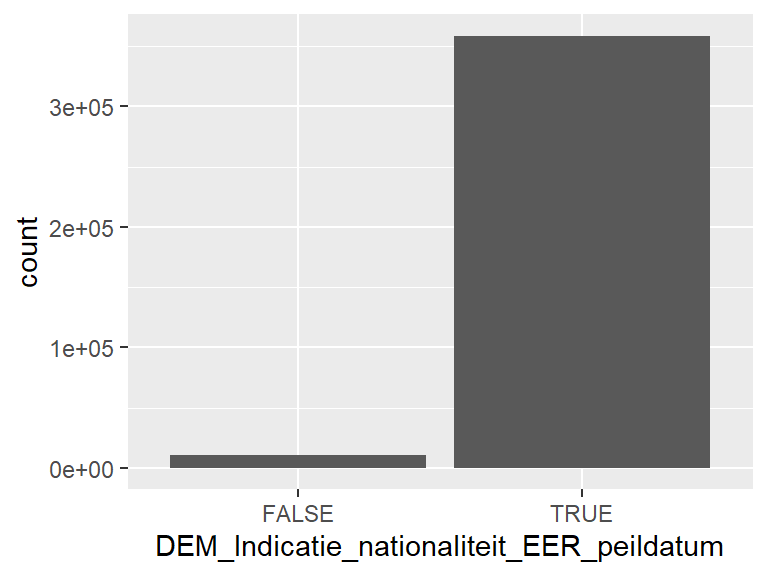

## DEM_Indicatie_internationale_student

| Feature | Result |
| --- | --- |
| Variable type | logical |
| Number of missing obs. | 0 (0 %) |
| Number of unique values | 2 |
| Mode | “TRUE” |

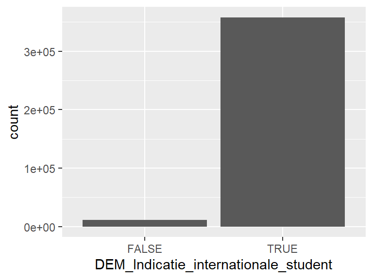

## INS_Bron

- The variable only takes one (non-missing) value: "1cho". The variable contains 0 % missing observations.

## INS_Verblijfsjaren_hoger_onderwijs_origineel

| Feature | Result |
| --- | --- |
| Variable type | numeric |
| Number of missing obs. | 16147 (4.37 %) |
| Number of unique values | 39 |
| Median | 4 |
| 1st and 3rd quartiles | 2; 6 |
| Min. and max. | 1; 39 |

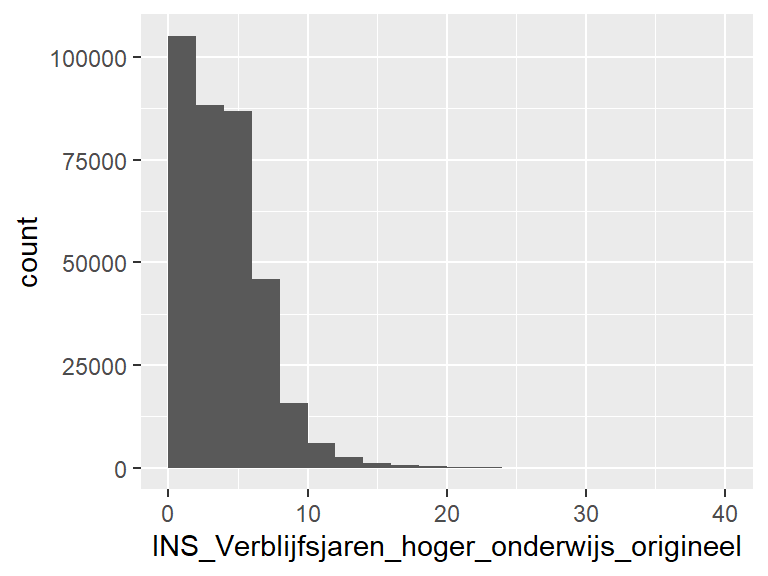